# How to avoid flight delays

## by Mohamed Ibrahim

## Investigation Overview

> Is there a relationship between the travelling month/day of month/day of week and the number of delayed flights? Is booking a flight in the morning have an effected on expected delay than booking an evening flight ?

## Dataset Overview

> The dataset contain all the domestic US flights data in 2007. This data include time, date, delays and etc...

## (Visualization 1)

> If you have booked a domestic flight in 2007, there is a 20% chance that you would have to waited for you flight a bit more than you anticipated. But little that you know that this 20% chance depend on what month are you travelling in

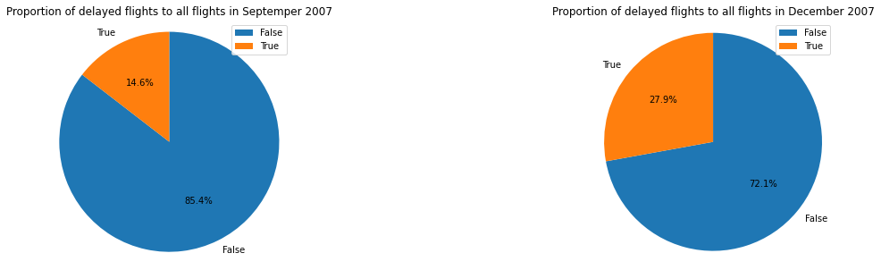

## (Visualization 2)

> However, you shouldn't expect big delays, ~75% of all delays are 45mins or less with a median of 25 mins

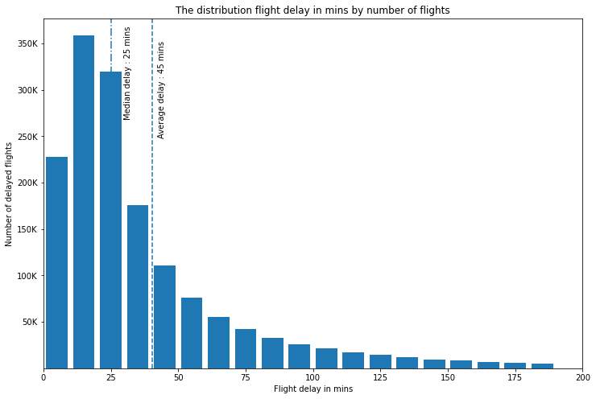

## (Visualization 3)

> Apart from trying to travel in Septemper than in Decmeber, you should try to book flight that have an early morning departure time. Flights that leave at night are more prone to delays than flights in the morning.

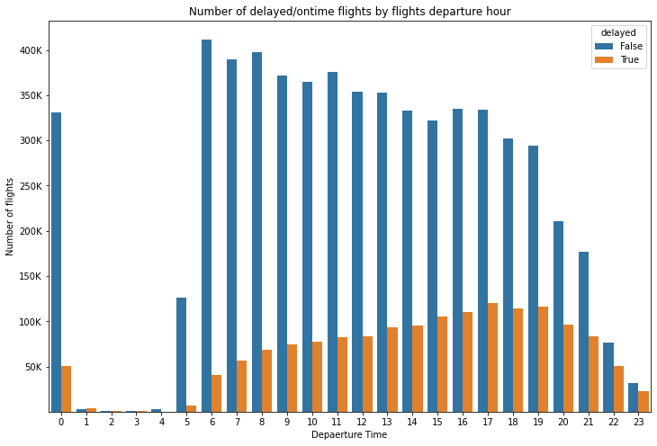

## (Visualization 4)

> They also have on average longer delays than the morning flights.

*note: flights that leave in the period from 1 am to 3 am have very high average delays but they are very rare

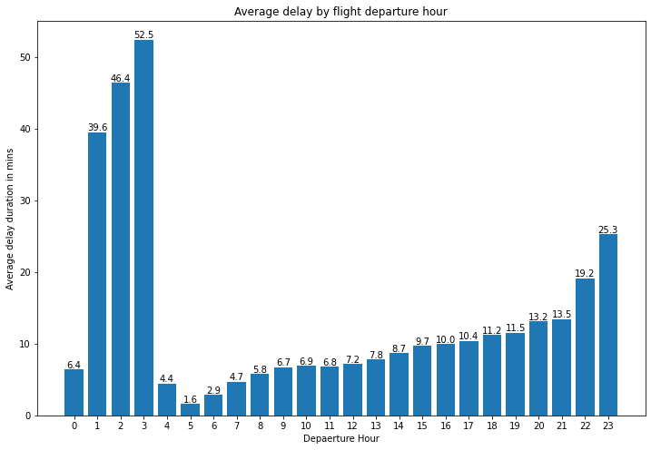